# Mental Health Outcomes in Gamers

#### GAD vs “whyplay”

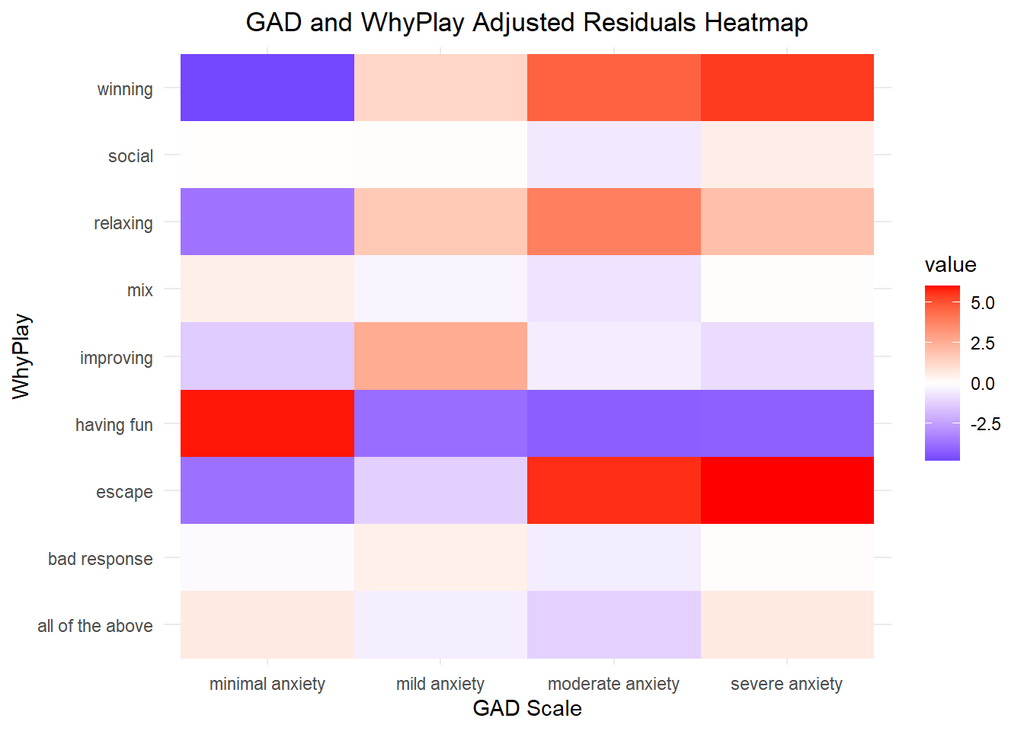

```r
expected_counts <- chisq.test(contingency_table_gad)$expected

# Calculate residuals
residuals <- contingency_table_gad - expected_counts

# Calculate adjusted residuals
adjusted_residuals <- residuals / sqrt(expected_counts)

# Print adjusted residuals
#print(adjusted_residuals)


residuals_df <- melt(adjusted_residuals)

# Create a heatmap
ggplot(residuals_df, aes(Var1, Var2, fill = value)) +
  geom_tile() +
  scale_fill_gradient2(low = "blue", mid = "white", high = "red", midpoint = 0) +
  labs(title = "GAD and WhyPlay Adjusted Residuals Heatmap", x = "GAD Scale", y = "WhyPlay") +
  theme_minimal()+
  theme(plot.title = element_text(hjust = 0.5))
```

The GAD vs “whyplay” heatmap clearly shows that “having fun” is most closely associated “minimal anxiety”, while “winning” and “escape” are more associated “moderate” and “severe” anxiety.

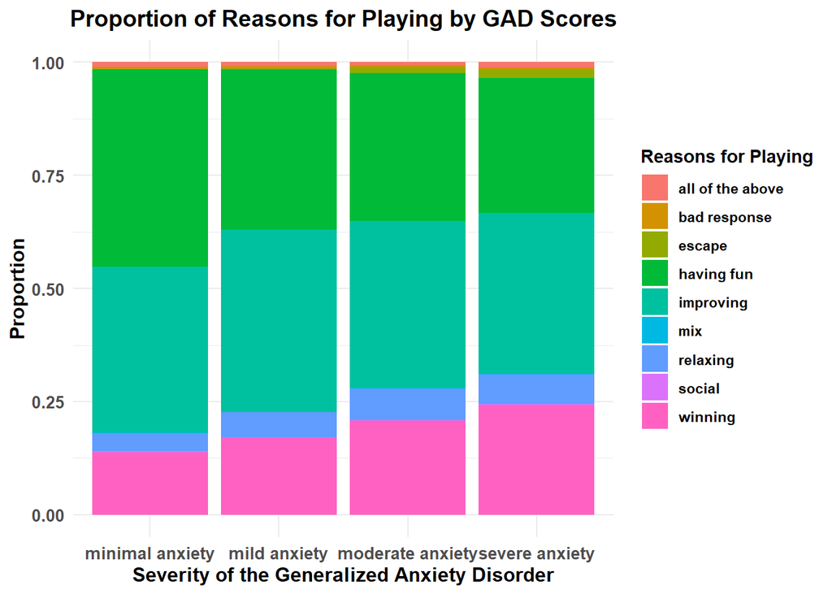

```r
ggplot(df, aes(x = GAD_ord, fill = cleaned_whyplay)) +
  geom_bar(position = "fill") +  # Use position = "fill" to show proportions
  ylab("Proportion") +           # Label the y-axis
  xlab("Severity of the Generalized Anxiety Disorder") +           # Label the x-axis
  labs(title = "Proportion of Reasons for Playing by GAD Scores",
       fill = "Reasons for Playing") +  # Rename the legend title
  theme_minimal() +
  theme(
    plot.title = element_text(hjust = 0.5, face = "bold", size = 14),  # Center and bold the title
    axis.title.x = element_text(face = "bold", size = 12),  # Bold and size for x-axis label
    axis.title.y = element_text(face = "bold", size = 12),  # Bold and size for y-axis label
    axis.text.x = element_text(face = "bold", size = 10),   # Bold the x-axis tick labels
    axis.text.y = element_text(face = "bold", size = 10),   # Bold the y-axis tick labels
    legend.title = element_text(face = "bold"),             # Bold the legend title
    legend.text = element_text(face = "bold")               # Bold the legend labels
  )
```

The above proportions graph offers another way of visualizing the relationship between “whyplay” and GAD. The bar height reflects the proportion of responses within each GAD severity category. This method of visualizations helps us understand the impact of “winning” on the GAD score.

#### GADE vs “whyplay”

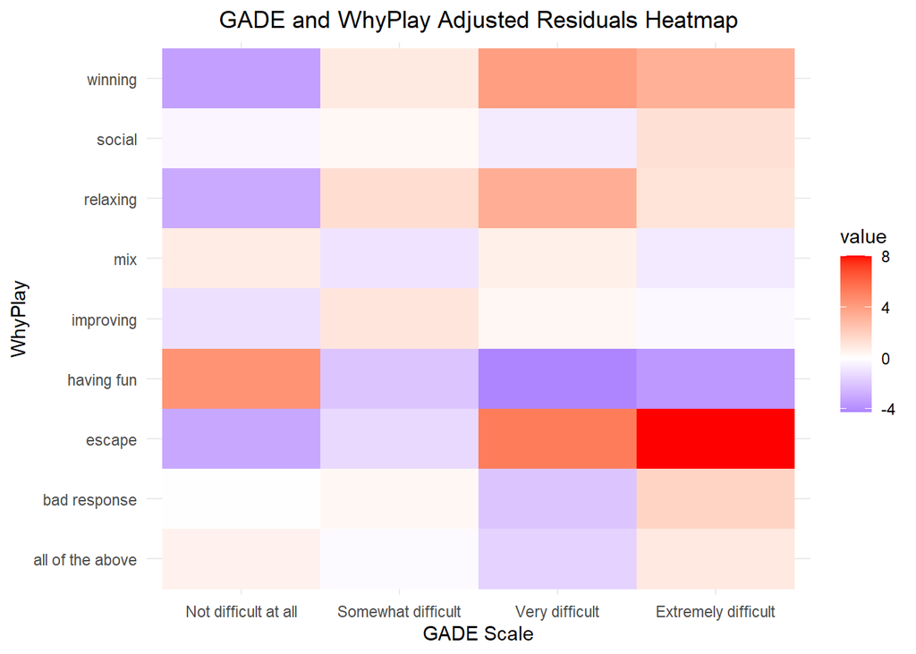

```r
expected_counts <- chisq.test(contingency_table_GADE)$expected

# Calculate residuals
residuals <- contingency_table_GADE - expected_counts

# Calculate adjusted residuals
adjusted_residuals <- residuals / sqrt(expected_counts)

# Print adjusted residuals
#print(adjusted_residuals)


residuals_df <- melt(adjusted_residuals)

# Create a heatmap
ggplot(residuals_df, aes(Var1, Var2, fill = value)) +
  geom_tile() +
  scale_fill_gradient2(low = "blue", mid = "white", high = "red", midpoint = 0) +
  labs(title = "GADE and WhyPlay Adjusted Residuals Heatmap", x = "GADE Scale", y = "WhyPlay") +
  theme_minimal()+
  theme(plot.title = element_text(hjust = 0.5))
```

This heatmap showing the residuals for GADE and “whyplay” tell a similar story to that of GAD. “having fun” is highly associated to positive mental health, in the context of anxiety disorders. “winning” and “escaping” as declared reasons why the respondents play video games once again are associated with negative outcomes. Though, “escaping”s affect is considerable higher.

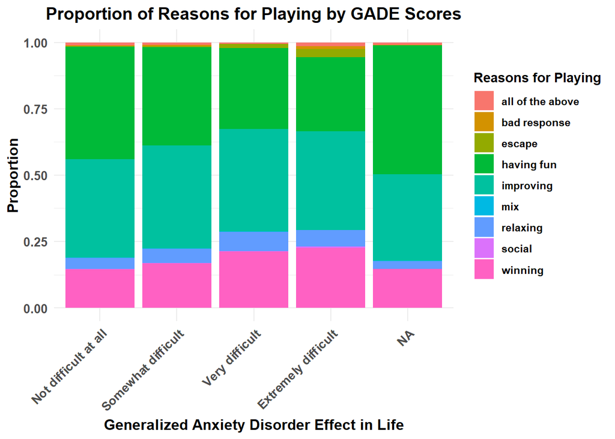

```r
ggplot(df, aes(x = GADE, fill = cleaned_whyplay)) +
  geom_bar(position = "fill") +  # Use position = "fill" to show proportions
  ylab("Proportion") +           # Label the y-axis
  xlab("Generalized Anxiety Disorder Effect in Life") +           # Label the x-axis
  labs(title = "Proportion of Reasons for Playing by GADE Scores",
       fill = "Reasons for Playing") +  # Rename the legend title
  theme_minimal() +
  theme(
    plot.title = element_text(hjust = 0.5, face = "bold", size = 14),  # Center and bold the title
    axis.title.x = element_text(face = "bold", size = 12),  # Bold and size for x-axis label
    axis.title.y = element_text(face = "bold", size = 12),  # Bold and size for y-axis label
    axis.text.x = element_text(face = "bold", size = 10, angle = 45, hjust = 1),   # Rotate and bold the x-axis tick labels
    axis.text.y = element_text(face = "bold", size = 10),   # Bold the y-axis tick labels
    legend.title = element_text(face = "bold"),             # Bold the legend title
    legend.text = element_text(face = "bold")               # Bold the legend labels
  )
```

We can examine this phenomenon more naively when looking at the proportions graph between GADE and “whyplay”. Once again, the relationship of “having fun”, “winning”, and “escape” to positive and negative outcomes can be seen.

#### SWL vs “whyplay”

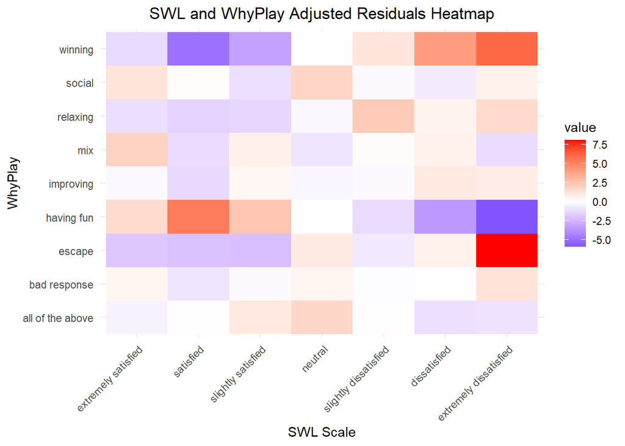

```r
expected_counts <- chisq.test(contingency_table_swl)$expected

# Calculate residuals
residuals <- contingency_table_swl - expected_counts

# Calculate adjusted residuals
adjusted_residuals <- residuals / sqrt(expected_counts)

# Print adjusted residuals
#print(adjusted_residuals)



residuals_df <- melt(adjusted_residuals)

# Create a heatmap
ggplot(residuals_df, aes(Var1, Var2, fill = value)) +
  geom_tile() +
  scale_fill_gradient2(low = "blue", mid = "white", high = "red", midpoint = 0) +
  labs(title = "SWL and WhyPlay Adjusted Residuals Heatmap", x = "SWL Scale", y = "WhyPlay") +
  theme_minimal()+
  theme(
    plot.title = element_text(hjust = 0.5),
    axis.text.x = element_text(angle = 45, hjust = 1)
  )
```

The heatmap above for SWL vs “whyplay” shows that, again, “having fun” is most strongly associated with positive outcomes, satisfaction with life in this case. The response “escape” and “winning” are highly associated with respondents who are extreme dissatisfied in life.

#### SPIN vs “whyplay”

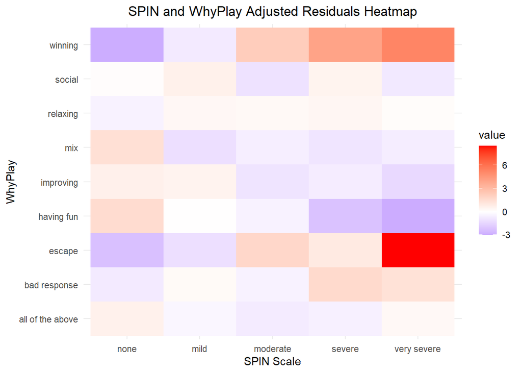

```r
expected_counts <- chisq.test(contingency_table_spin)$expected

# Calculate residuals
residuals <- contingency_table_spin - expected_counts

# Calculate adjusted residuals
adjusted_residuals <- residuals / sqrt(expected_counts)

# Print adjusted residuals
#print(adjusted_residuals)


residuals_df <- melt(adjusted_residuals)

# Create a heatmap
ggplot(residuals_df, aes(Var1, Var2, fill = value)) +
  geom_tile() +
  scale_fill_gradient2(low = "blue", mid = "white", high = "red", midpoint = 0) +
  labs(title = "SPIN and WhyPlay Adjusted Residuals Heatmap", x = "SPIN Scale", y = "WhyPlay") +
  theme_minimal()+
  theme(plot.title = element_text(hjust = 0.5))
```

With regards to indicators of social phobia, the most apparent indicator is that of “escape” and very severe outcomes. The typical pattern of “having fun” being associated with better outcomes and “winning” having the inverse effect is also present.

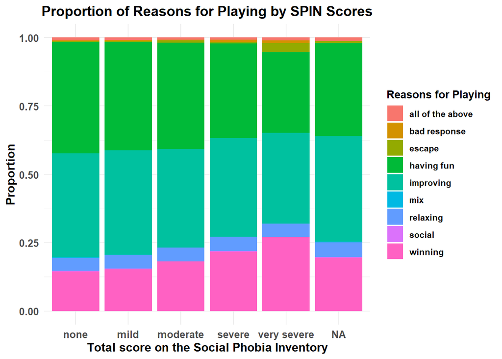

```r
ggplot(df, aes(x = SPIN_ord, fill = cleaned_whyplay)) +
  geom_bar(position = "fill") +  # Use position = "fill" to show proportions
  ylab("Proportion") +           # Label the y-axis
  xlab("Total score on the Social Phobia Inventory") +          # Label the x-axis
  labs(title = "Proportion of Reasons for Playing by SPIN Scores",
       fill = "Reasons for Playing") +  # Rename the legend title
  theme_minimal() +
  theme(
    plot.title = element_text(hjust = 0.5, face = "bold", size = 14),  # Center and bold the title
    axis.title.x = element_text(face = "bold", size = 12),  # Bold and size for x-axis label
    axis.title.y = element_text(face = "bold", size = 12),  # Bold and size for y-axis label
    axis.text.x = element_text(face = "bold", size = 10),   # Bold the x-axis tick labels
    axis.text.y = element_text(face = "bold", size = 10),   # Bold the y-axis tick labels
    legend.title = element_text(face = "bold"),             # Bold the legend title
    legend.text = element_text(face = "bold")               # Bold the legend labels
  )
```

### ANOVA test for Total time spent and GAD_ordinal variables

As we have seen before from the histogram distributions before that the hours spent playing games and watching streams is different for different levels of anxiety. Now in this part we will look if the amount of time people spend on gaming and streaming is signifantly different depending on their level of Generalized Anxiety Disorder (GAD). So we state the following hypotheses:

Null hypothesis: There is no difference in the mean combined hours spent on gaming and streaming among the different levels of GAD. Alternate hypothesis: At least one group mean of the combined hours spent on gaming and streaming is different from the others among the different levels of GAD.

```r
# Combine the hours played and streams into a new variable
df$hrs_stream_combined <- df_clean$streams + hrs_GAD_filtered_clean$Hours

# Perform the ANOVA test
anova_result_combined <- aov(hrs_stream_combined ~ GAD_ord, data = df)

# Summarize the ANOVA results
summary(anova_result_combined)
```

```
##                Df  Sum Sq Mean Sq F value  Pr(>F)
## GAD_ord         3   13618    4539    24.9 4.3e-16 ***
## Residuals   12530 2279229     182
## ---
## Signif. codes:  0 '***' 0.001 '**' 0.01 '*' 0.05 '.' 0.1 ' ' 1
## 930 observations deleted due to missingness
```

So, at least one group (for example, those with mild anxiety) spends a different amount of time gaming and streaming compared to another group (for example, those with severe anxiety). Next yo understand which specific groups are different, we want to conduct post-hoc tests (like Tukey’s HSD) to compare the means between each pair of GAD levels.

#### Post hoc test

The Tukey HSD test will compare the means of every possible pair of groups (levels of GAD) to see which means are significantly different from each other.

```r
# Perform the ANOVA
anova_result <- aov(hrs_stream_combined ~ GAD_ord, data = df)

# Perform Tukey HSD post-hoc test
tukey_result <- TukeyHSD(anova_result)

# Display the Tukey HSD results
print(tukey_result)
```

```
##   Tukey multiple comparisons of means
##     95% family-wise confidence level
##
## Fit: aov(formula = hrs_stream_combined ~ GAD_ord, data = df)
##
## $GAD_ord
##                                  diff     lwr  upr p adj
## mild anxiety-minimal anxiety     1.09  0.3689 1.82 0.001
## moderate anxiety-minimal anxiety 2.24  1.2393 3.23 0.000
## severe anxiety-minimal anxiety   3.83  2.3980 5.27 0.000
## moderate anxiety-mild anxiety    1.14  0.0598 2.23 0.034
## severe anxiety-mild anxiety      2.74  1.2439 4.24 0.000
## severe anxiety-moderate anxiety  1.60 -0.0489 3.25 0.061
```

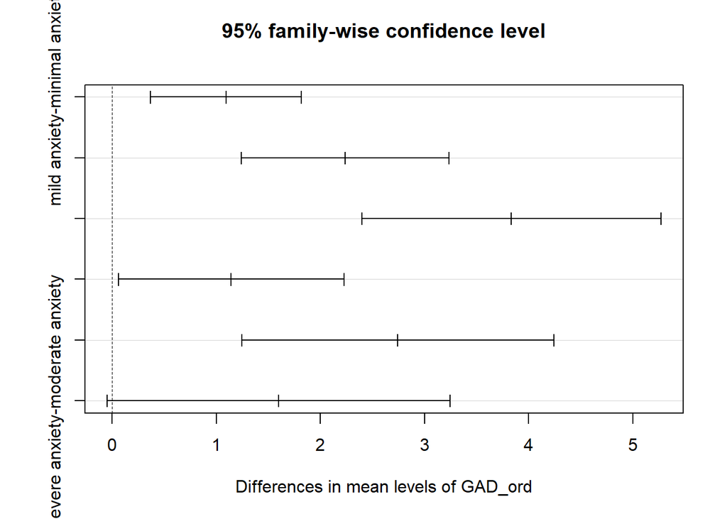

```r
# Optional: Plot the Tukey HSD results
plot(tukey_result)
```

## Key Findings

Team 5’s analysis reveals significant relationships between video game habits and mental health outcomes. First, increasing hours spent playing video games and streaming is associated with higher stream counts, as indicated by significant ANOVA results across all comparisons. This suggests that gamers who spend more hours playing are more likely to be heavily involved in the gaming community, leading to increased streaming activity.

Additionally, SPIN_T scores significantly increase from Low to Very High levels of gaming, indicating that greater gaming engagement correlates with heightened psychological distress.

Lastly, our chi-squared analysis shows that respondents who play video games for enjoyment report better mental health outcomes than those motivated by competition or escapism.

As causality cannot be determined, Team 5 caveats this analysis by adding that pre-exiting mental health conditions and other life stressors could be a contributing factor to negative mental health outcomes. However, a correlative effect is clearly seen as exposed by the ANOVA and Chi-Sqaured tests we conducted.

## Recommendations

Team 5 recommends passing our findings to social scientists to adjust the survey instruments. Collecting more comprehensive demographic information would be invaluable, including factors such as respondents’ socioeconomic status (e.g., ability to afford the cost of living), family history of mental health diagnoses, and other relevant contextual data. This information could help identify potential confounding variables and provide deeper insights into the relationships we observed.

Given the non-normality of the inventory scores, we also recommend conducting logistic regression to observe the interaction of multiple predictors against the outcomes (inventory scores). Adding this layer of complexity would allow us to more effectively model how gaming habits affect mental health outcomes in gamers.

## References

Greenspace Mental Health. (2020). *Social Anxiety SPIN Greenspace (US)*. https://greenspacehealth.com/en-us/social-anxiety-spin/

Marian Sauter, & Dejan Draschkow. (2017). *Gaming Habits and Psychological Well-being: An international dataset about the Anxiety, Life Satisfaction and Social Phobia of over 13000 gamers*. https://osf.io/vnbxk/

Sapra, A., Bhandari, P., Sharma, S., Chanpura, T., & Lopp, L. (2020). Using Generalized Anxiety Disorder-2 (GAD-2) and GAD-7 in a Primary Care Setting. *Cureus*, *12*(5), e8224. https://doi.org/10.7759/cureus.8224

Yun, Y. H., Rhee, Y. E., Kang, E., & Sim, J. (2019). The Satisfaction with Life Scale and the Subjective Well-Being Inventory in the General Korean Population: Psychometric Properties and Normative Data. *International Journal of Environmental Research and Public Health*, *16*(9), 1538. https://doi.org/10.3390/ijerph16091538